# Flowcar_paper2_sEBR

Ben Cowley

22 January 2019

# Research Questions

1. Does the (approximate) baseline sEBR of each participant predict their performance or Flow experience?
2. Does sEBR variation across sessions (of each participant) affect their perceived cognitive performance, i.e. Flow, PI, skill:demand?
3. Does sEBR variation across sessions, and actual performance (i.e. duration, session-wise power-law slope), affect perceived cognitive performance (Flow, PI, skill:demand)?
4. Does sEBR variation across sessions, and expected-performance difference (i.e. LC-to-duration distance) affect perceived cognitive performance (Flow, PI, skill:demand)?

## RQ1

RQ1 is addressed by participant-wise mean Flow, learning curve slope, mean sEBR (across sessions). We then calculate the absolute residuals as the agreement between observations and the linear model of LC and sEBR.

```r
df <- read_csv("rq1_between.csv")
lm.fit <- with(df, lm(LC ~ sEBR)) #get the linear fit of LC and sEBR
df$dst <- abs(resid(lm.fit)) #calculate the exact residuals as 'distance'
head(df, n = 9)
```

| Part | FM | LC | sEBR | dst |
| --- | --- | --- | --- | --- |
| 1 | 5.1 | -0.067 | 31 | 0.00986 |
| 2 | 5.18 | -0.049 | 6.42 | 0.00873 |
| 3 | 5.36 | -0.077 | 35.3 | 0.00324 |
| 4 | 4.4 | -0.099 | 10.4 | 0.0382 |
| 5 | 5.44 | -0.049 | 6.1 | 0.00849 |
| 6 | 5.22 | -0.071 | 21.4 | 0.00161 |
| 7 | 4.69 | -0.083 | 22.6 | 0.0127 |
| 8 | 4.94 | -0.041 | 6.46 | 0.0168 |
| 9 | 5.25 | -0.059 | 15 | 0.0054 |

### RQ1 Analysis

RQ1 is positively answered by the analysis from the first paper. LC and sEBR are weakly correlated, but the residual distance measure appears to be strongly correlated to mean Flow, motivating an interaction model (for which the data is first centered). The output of this model, i.e. the overall 3-way relationship, is a bit hard to interpret (some effort has been made already in the paper): but conceivably the simplest explanation is that performance determines Flow, modulated by baseline attention capacity indexed by sEBR.

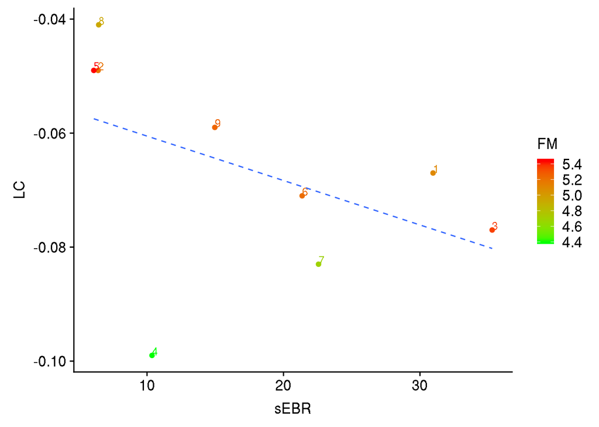

```r
ggplot(df, aes(x=sEBR, y=LC, color=FM)) +
  geom_point() +
  geom_text(aes(label=Part), hjust=0, vjust=0) +
  geom_smooth(method="lm", formula=y~x, se=F, alpha=0.8, linetype="dashed", size = 0.5) +
  scale_color_gradient(low="green", high="red")
```

```r
# Shapiro-Wilk testing and plots show sEBR data meets normality assumption, model distance metric doesn't
shapiro.test(df$sEBR)
```

```
##
##  Shapiro-Wilk normality test
##
## data:  df$sEBR
## W = 0.89057, p-value = 0.2022
```

```r
shapiro.test(df$dst)
```

```
##
##  Shapiro-Wilk normality test
##
## data:  df$dst
## W = 0.78409, p-value = 0.01342
```

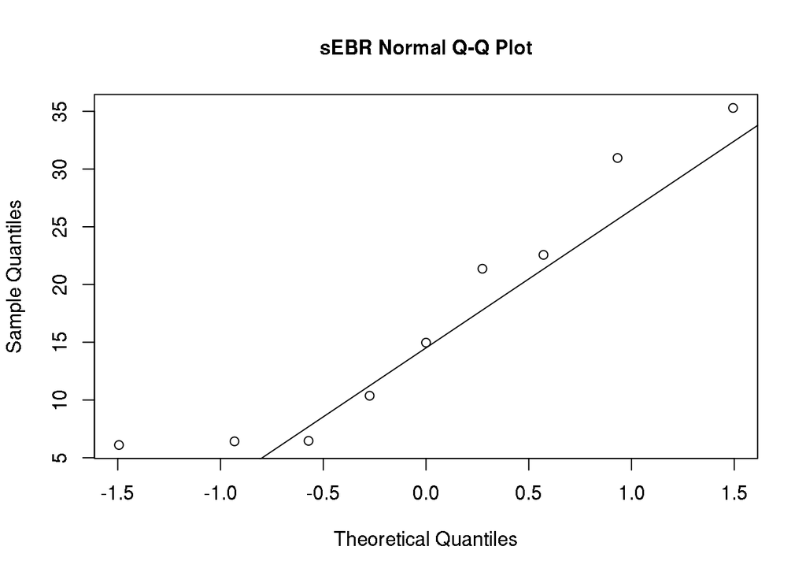

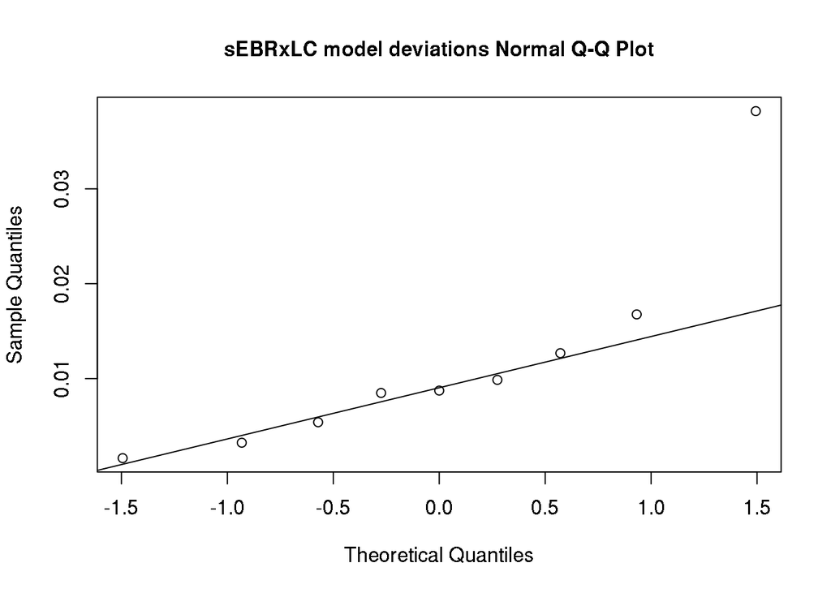

```r
with(df, {qqnorm(sEBR, main = "sEBR Normal Q-Q Plot")
          qqline(sEBR)
          qqnorm(dst, main = "sEBRxLC model deviations Normal Q-Q Plot")
          qqline(dst)})
```

```r
with(df, cor.test(LC, sEBR, method = "spearman"))
```

```
##
##  Spearman's rank correlation rho
##
## data:  LC and sEBR
## S = 193.31, p-value = 0.08054
## alternative hypothesis: true rho is not equal to 0
## sample estimates:
##       rho
## -0.610884
```

```r
with(df, cor.test(FM, sEBR, method = "spearman"))
```

```
##
##  Spearman's rank correlation rho
##
## data:  FM and sEBR
## S = 128, p-value = 0.8801
## alternative hypothesis: true rho is not equal to 0
## sample estimates:
##         rho
## -0.06666667
```

```r
with(df, cor.test(FM, dst, method = "spearman"))
```

```
##
##  Spearman's rank correlation rho
##
## data:  FM and dst
## S = 220, p-value = 0.008267
## alternative hypothesis: true rho is not equal to 0
## sample estimates:
##        rho
## -0.8333333
```

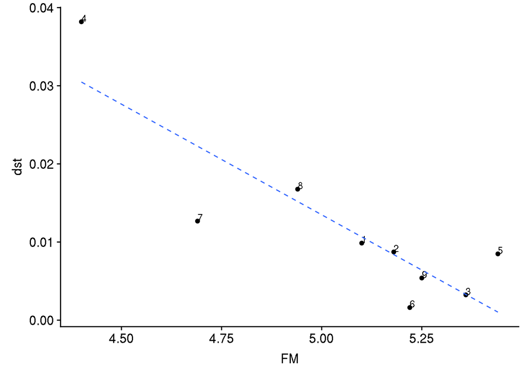

```r
ggplot(df, aes(x=FM, y=dst)) +
  geom_point() +
  geom_text(aes(label=Part), hjust=0, vjust=0) +
  geom_smooth(method="lm", formula=y~x, se=F, alpha=0.8, linetype="dashed", size = 0.5)
```

```r
df.ctr <- df %>% mutate_at(vars(-Part), funs(scale), scale = FALSE) %>% mutate_at(vars(-Part), funs(drop))
fiti <- with(df.ctr, lm(sEBR ~ FM*LC))
summ(fiti)
```

```
## MODEL INFO:
## Observations: 9
## Dependent Variable: sEBR
## Type: OLS linear regression
##
## MODEL FIT:
## F(3,5) = 12.53, p = 0.01
## R² = 0.88
## Adj. R² = 0.81
##
## Standard errors: OLS
##                 Est.   S.E. t val.    p
## (Intercept)     4.38   1.94   2.26 0.07  .
## FM              7.52   7.52   1.00 0.36
## LC           -683.66 121.51  -5.63 0.00 **
## FM:LC       -1280.41 325.55  -3.93 0.01  *
```

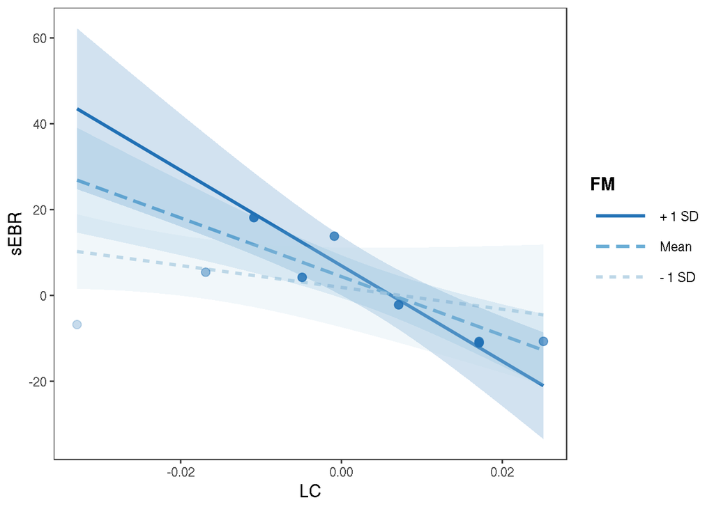

```r
ss <- sim_slopes(fiti, pred = "LC", modx = "FM", jnalpha = 0.05, johnson_neyman = TRUE, jnplot = TRUE, cond.int = TRUE)
interact_plot(fiti, pred = "LC", modx = "FM", centered = "none", plot.points = TRUE, interval = TRUE, point.shape = TRUE)
```

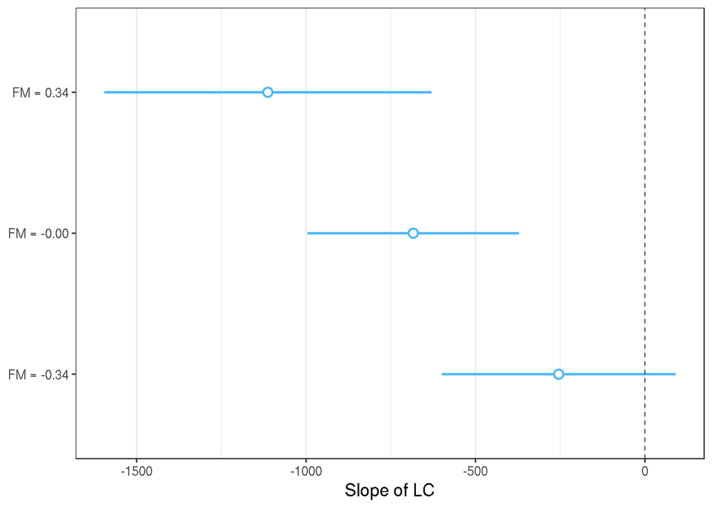

```r
plot(ss)
```

```r
as_huxtable(ss)
```

| Value of FM | Slope of LC |
| --- | --- |
| 0.34 | -1112.84 (187.9)*** |
| -0.00 | -683.66 (121.51)*** |
| -0.34 | -254.48 (134.31) |

```r
ss
```

```
## JOHNSON-NEYMAN INTERVAL
##
## When FM is OUTSIDE the interval [-1.40, -0.28], the slope of LC is p <
## .05.
##
## Note: The range of observed values of FM is [-0.66, 0.38]
```

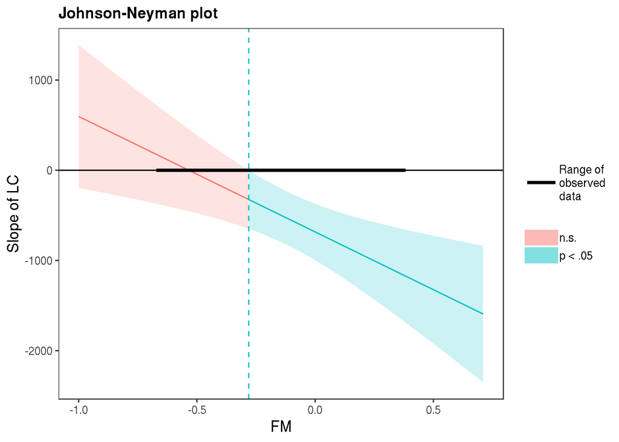

```
## SIMPLE SLOPES ANALYSIS
##
## Slope of LC when FM =  0.34 (+ 1 SD):
##      Est.   S.E. t val.    p
##  -1112.84 187.90  -5.92 0.00
## Conditional intercept when FM =  0.34 (+ 1 SD):
##  Est. S.E. t val.    p
##  6.90 2.68   2.58 0.05
##
## Slope of LC when FM = -0.00 (Mean):
##     Est.   S.E. t val.    p
##  -683.66 121.51  -5.63 0.00
## Conditional intercept when FM = -0.00 (Mean):
##  Est. S.E. t val.    p
##  4.38 1.94   2.26 0.07
##
## Slope of LC when FM = -0.34 (- 1 SD):
##     Est.   S.E. t val.    p
##  -254.48 134.31  -1.89 0.12
## Conditional intercept when FM = -0.34 (- 1 SD):
##  Est. S.E. t val.    p
##  1.86 3.62   0.51 0.63
```

Discovery of this interaction motivates us to look at the session-level relationships between sEBR, self-reports, and performance measures.

## RQ2-4

RQ2-4 are addressed by session-wise data, either gathered directly at the session level (sEBR, skill:demand self-reports), or aggregated from run-level data (performance, Flow and PI self-reports). Additional variables are created by per-session power-law fits, i.e. fitting linear models to the log-log transformed duration by runs within each session; the slope and intercept are added to the dataframe.

NOTE: when we aggregate the distance-from-powerlaw variable within sessions, we tend to be summing and dividing both positive and negative numbers, with the result that per-session distance scores tend to get very small: implying this approach might be non-optimal.

```r
## DATA WRANGLING ----
blk <- read_rds("BLINK_ANALYSIS/blink_data.RData")
fssl <- read_rds("fss_learning.RData")

inc.ssn <- c(1, 5, 6, 7, 8)

brate <- cbind(blk$blinkrate.session1, blk$blinkrate.session5, blk$blinkrate.session6, blk$blinkrate.session7, blk$blinkrate.session8)
long.br <- gather(as.data.frame(t(brate)), "Parti", "brate")
ssn.lc <- filter(fssl, Session %in% inc.ssn) %>% group_by(Participant, Session) %>% summarise(ssn.lc = as.numeric(lm(ln.duration ~ log(Run))$coefficients[2]), ssn.in = as.numeric(lm(ln.duration ~ log(Run))$coefficients[1]))

df <- filter(fssl, Session %in% inc.ssn) %>%
  select(-Run, -cumrun, -slope, -intercept, -flow_z, -demand, -skill, -skilldemand) %>%
  group_by(Participant, Session) %>%
  summarise_all(funs(mean), na.rm = TRUE)
df <- df %>%
  bind_cols(ssn.lc, long.br, filter(fssl, Session %in% inc.ssn & Run == 5) %>% select(demand, skill, skilldemand)) %>%
  select(1:2, brate, duration, ln.duration, learning_curve, distance, ssn.lc, ssn.in, everything(), -Participant1, -Session1, -Parti) %>%
  mutate(skidem = skill - demand)

#### Centering steps: br * Participant, self-rep / perf x all ####
df <- group_by(df, Participant) %>% mutate_at(vars(brate), funs(scale), scale = FALSE)
df <- df %>% mutate_at(vars(-Participant, -Session, -brate), funs(scale), scale = FALSE)
```

```r
## SIMPLE VISUALS ----
## PCA
pca <- prcomp(filter(df[,3:20], !is.na(brate)), scale. = TRUE)
summary(pca)
```

```
## Importance of components:
##                           PC1    PC2    PC3    PC4     PC5     PC6     PC7
## Standard deviation     2.3842 1.9925 1.6429 1.2075 1.05943 0.94462 0.81889
## Proportion of Variance 0.3158 0.2206 0.1499 0.0810 0.06235 0.04957 0.03725
## Cumulative Proportion  0.3158 0.5363 0.6863 0.7673 0.82965 0.87922 0.91647
##                            PC8     PC9    PC10   PC11    PC12    PC13
## Standard deviation     0.78606 0.58914 0.47589 0.4025 0.38489 0.04297
## Proportion of Variance 0.03433 0.01928 0.01258 0.0090 0.00823 0.00010
## Cumulative Proportion  0.95080 0.97008 0.98267 0.9917 0.99990 1.00000
##                             PC14      PC15      PC16      PC17      PC18
## Standard deviation     1.089e-14 3.728e-15 1.828e-15 9.522e-16 2.721e-16
## Proportion of Variance 0.000e+00 0.000e+00 0.000e+00 0.000e+00 0.000e+00
## Cumulative Proportion  1.000e+00 1.000e+00 1.000e+00 1.000e+00 1.000e+00
```

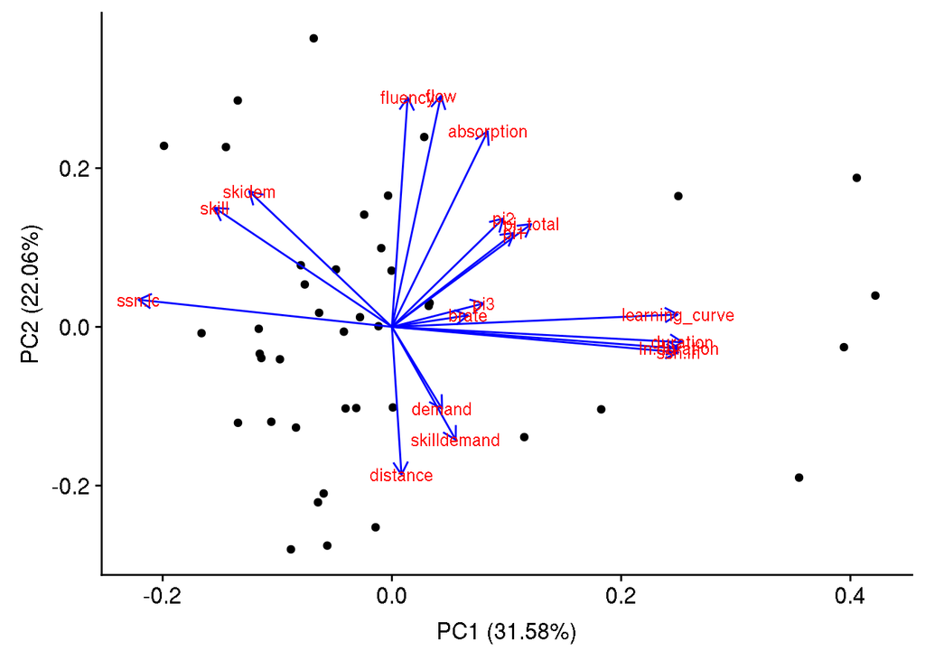

```r
autoplot(pca, loadings = TRUE, loadings.colour = 'blue', loadings.label = TRUE, loadings.label.size = 3)
```

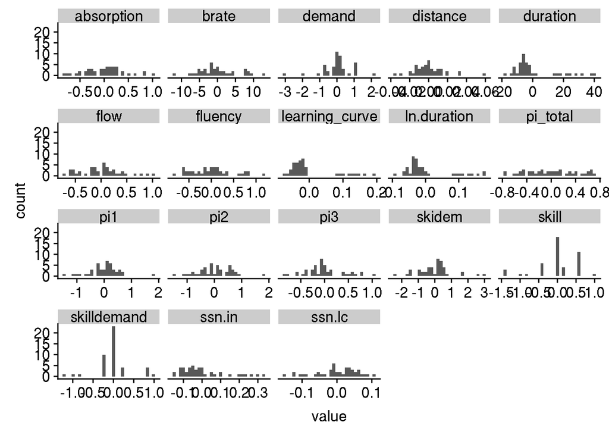

```r
# histograms of everything
ggplot(gather(df[-(1:2)]), aes(value)) +
  geom_histogram() +
  facet_wrap(~key, scales = 'free_x')
```

## RQ2

“Does sEBR variation across sessions (of each participant) affect their perceived cognitive performance, i.e. Flow, PI, skill:demand?”

First we check the main effects of each self-report variable wrt sEBR, trying to see which ‘family’ of self-report (Flow, PI, skill:demand) has the strongest relationships.

```r
# blink rate predicted by flow components
summary(lmer(brate ~ flow + (1 | Participant), data = df))
```

```
## Linear mixed model fit by REML. t-tests use Satterthwaite's method [
## lmerModLmerTest]
## Formula: brate ~ flow + (1 | Participant)
##    Data: df
##
## REML criterion at convergence: 246.9
##
## Scaled residuals:
##     Min      1Q  Median      3Q     Max
## -2.1458 -0.6952 -0.1897  0.4388  2.4542
##
## Random effects:
##  Groups      Name        Variance  Std.Dev.
##  Participant (Intercept) 1.383e-30 1.176e-15
##  Residual                2.844e+01 5.333e+00
## Number of obs: 41, groups:  Participant, 9
##
## Fixed effects:
##             Estimate Std. Error       df t value Pr(>|t|)
## (Intercept)  0.00442    0.83304 39.00000   0.005    0.996
## flow         0.48719    2.01159 39.00000   0.242    0.810
##
## Correlation of Fixed Effects:
##      (Intr)
## flow 0.022
```

```r
summary(lmer(brate ~ fluency + (1 | Participant), data = df))
```

```
## Linear mixed model fit by REML. t-tests use Satterthwaite's method [
## lmerModLmerTest]
## Formula: brate ~ fluency + (1 | Participant)
##    Data: df
##
## REML criterion at convergence: 247.1
##
## Scaled residuals:
##     Min      1Q  Median      3Q     Max
## -2.1461 -0.7300 -0.1698  0.4227  2.4478
##
## Random effects:
##  Groups      Name        Variance  Std.Dev.
##  Participant (Intercept) 1.383e-30 1.176e-15
##  Residual                2.842e+01 5.331e+00
## Number of obs: 41, groups:  Participant, 9
##
## Fixed effects:
##              Estimate Std. Error        df t value Pr(>|t|)
## (Intercept)  0.007915   0.833097 39.000000   0.010    0.992
## fluency      0.512392   1.819462 39.000000   0.282    0.780
##
## Correlation of Fixed Effects:
##         (Intr)
## fluency 0.034
```

```r
summary(lmer(brate ~ absorption + (1 | Participant), data = df))
```

```
## Linear mixed model fit by REML. t-tests use Satterthwaite's method [
## lmerModLmerTest]
## Formula: brate ~ absorption + (1 | Participant)
##    Data: df
##
## REML criterion at convergence: 247
##
## Scaled residuals:
##     Min      1Q  Median      3Q     Max
## -2.1639 -0.6522 -0.1950  0.4754  2.4620
##
## Random effects:
##  Groups      Name        Variance  Std.Dev.
##  Participant (Intercept) 1.385e-30 1.177e-15
##  Residual                2.847e+01 5.336e+00
## Number of obs: 41, groups:  Participant, 9
##
## Fixed effects:
##               Estimate Std. Error         df t value Pr(>|t|)
## (Intercept) -0.0001346  0.8332669 39.0000000   0.000    1.000
## absorption   0.2758788  2.0013110 39.0000000   0.138    0.891
##
## Correlation of Fixed Effects:
##            (Intr)
## absorption -0.001
```

```r
# blink rate predicted by perceived-importance components
summary(lmer(brate ~ pi1 + (1 | Participant), data = df))
```

```
## Linear mixed model fit by REML. t-tests use Satterthwaite's method [
## lmerModLmerTest]
## Formula: brate ~ pi1 + (1 | Participant)
##    Data: df
##
## REML criterion at convergence: 247.5
##
## Scaled residuals:
##     Min      1Q  Median      3Q     Max
## -2.1248 -0.6338 -0.1755  0.4608  2.4444
##
## Random effects:
##  Groups      Name        Variance  Std.Dev.
##  Participant (Intercept) 1.384e-30 1.176e-15
##  Residual                2.845e+01 5.334e+00
## Number of obs: 41, groups:  Participant, 9
##
## Fixed effects:
##              Estimate Std. Error        df t value Pr(>|t|)
## (Intercept)  0.003228   0.833087 39.000000   0.004    0.997
## pi1          0.330887   1.510575 39.000000   0.219    0.828
##
## Correlation of Fixed Effects:
##     (Intr)
## pi1 0.018
```

```r
summary(lmer(brate ~ pi2 + (1 | Participant), data = df))         # .
```

```
## Linear mixed model fit by REML. t-tests use Satterthwaite's method [
## lmerModLmerTest]
## Formula: brate ~ pi2 + (1 | Participant)
##    Data: df
##
## REML criterion at convergence: 244.4
##
## Scaled residuals:
##     Min      1Q  Median      3Q     Max
## -2.0654 -0.6489 -0.1671  0.5705  2.0234
##
## Random effects:
##  Groups      Name        Variance  Std.Dev.
##  Participant (Intercept) 1.272e-30 1.128e-15
##  Residual                2.615e+01 5.114e+00
## Number of obs: 41, groups:  Participant, 9
##
## Fixed effects:
##             Estimate Std. Error       df t value Pr(>|t|)
## (Intercept) -0.03664    0.79885 39.00000  -0.046   0.9636
## pi2          2.50392    1.34237 39.00000   1.865   0.0697 .
## ---
## Signif. codes:  0 '***' 0.001 '**' 0.01 '*' 0.05 '.' 0.1 ' ' 1
##
## Correlation of Fixed Effects:
##     (Intr)
## pi2 -0.025
```

```r
summary(lmer(brate ~ pi3 + (1 | Participant), data = df))
```

```
## Linear mixed model fit by REML. t-tests use Satterthwaite's method [
## lmerModLmerTest]
## Formula: brate ~ pi3 + (1 | Participant)
##    Data: df
##
## REML criterion at convergence: 246.9
##
## Scaled residuals:
##     Min      1Q  Median      3Q     Max
## -2.1941 -0.6479 -0.1664  0.4905  2.4592
##
## Random effects:
##  Groups      Name        Variance  Std.Dev.
##  Participant (Intercept) 1.385e-30 1.177e-15
##  Residual                2.848e+01 5.337e+00
## Number of obs: 41, groups:  Participant, 9
##
## Fixed effects:
##              Estimate Std. Error        df t value Pr(>|t|)
## (Intercept)  0.002073   0.834870 39.000000   0.002    0.998
## pi3         -0.088535   2.079078 39.000000  -0.043    0.966
##
## Correlation of Fixed Effects:
##     (Intr)
## pi3 -0.058
```

```r
summary(lmer(brate ~ pi_total + (1 | Participant), data = df))
```

```
## Linear mixed model fit by REML. t-tests use Satterthwaite's method [
## lmerModLmerTest]
## Formula: brate ~ pi_total + (1 | Participant)
##    Data: df
##
## REML criterion at convergence: 246
##
## Scaled residuals:
##     Min      1Q  Median      3Q     Max
## -2.0127 -0.6715 -0.2230  0.6271  2.2520
##
## Random effects:
##  Groups      Name        Variance  Std.Dev.
##  Participant (Intercept) 1.353e-30 1.163e-15
##  Residual                2.782e+01 5.274e+00
## Number of obs: 41, groups:  Participant, 9
##
## Fixed effects:
##             Estimate Std. Error      df t value Pr(>|t|)
## (Intercept)  -0.0184     0.8239 39.0000  -0.022    0.982
## pi_total      1.9508     2.0205 39.0000   0.966    0.340
##
## Correlation of Fixed Effects:
##          (Intr)
## pi_total -0.023
```

```r
# blink rate predicted by skill-demand components
summary(lmer(brate ~ skill + (1 | Participant), data = df))       # *
```

```
## Linear mixed model fit by REML. t-tests use Satterthwaite's method [
## lmerModLmerTest]
## Formula: brate ~ skill + (1 | Participant)
##    Data: df
##
## REML criterion at convergence: 241.3
##
## Scaled residuals:
##      Min       1Q   Median       3Q      Max
## -2.66307 -0.64491 -0.01001  0.64523  1.98866
##
## Random effects:
##  Groups      Name        Variance  Std.Dev.
##  Participant (Intercept) 1.178e-30 1.086e-15
##  Residual                2.423e+01 4.922e+00
## Number of obs: 41, groups:  Participant, 9
##
## Fixed effects:
##             Estimate Std. Error       df t value Pr(>|t|)
## (Intercept) -0.01738    0.76871 39.00000  -0.023   0.9821
## skill       -3.56232    1.36098 39.00000  -2.617   0.0125 *
## ---
## Signif. codes:  0 '***' 0.001 '**' 0.01 '*' 0.05 '.' 0.1 ' ' 1
##
## Correlation of Fixed Effects:
##       (Intr)
## skill 0.009
```

```r
summary(lmer(brate ~ demand + (1 | Participant), data = df))
```

```
## Linear mixed model fit by REML. t-tests use Satterthwaite's method [
## lmerModLmerTest]
## Formula: brate ~ demand + (1 | Participant)
##    Data: df
##
## REML criterion at convergence: 246.3
##
## Scaled residuals:
##     Min      1Q  Median      3Q     Max
## -1.9854 -0.7572 -0.2384  0.6364  2.5135
##
## Random effects:
##  Groups      Name        Variance  Std.Dev.
##  Participant (Intercept) 1.317e-30 1.148e-15
##  Residual                2.707e+01 5.203e+00
## Number of obs: 41, groups:  Participant, 9
##
## Fixed effects:
##             Estimate Std. Error       df t value Pr(>|t|)
## (Intercept)  0.05562    0.81352 39.00000   0.068    0.946
## demand      -1.42536    1.00027 39.00000  -1.425    0.162
##
## Correlation of Fixed Effects:
##        (Intr)
## demand -0.048
```

```r
summary(lmer(brate ~ skilldemand + (1 | Participant), data = df))
```

```
## Linear mixed model fit by REML. t-tests use Satterthwaite's method [
## lmerModLmerTest]
## Formula: brate ~ skilldemand + (1 | Participant)
##    Data: df
##
## REML criterion at convergence: 246.2
##
## Scaled residuals:
##     Min      1Q  Median      3Q     Max
## -2.4578 -0.6599 -0.1560  0.4620  2.2346
##
## Random effects:
##  Groups      Name        Variance  Std.Dev.
##  Participant (Intercept) 1.362e-30 1.167e-15
##  Residual                2.801e+01 5.292e+00
## Number of obs: 41, groups:  Participant, 9
##
## Fixed effects:
##             Estimate Std. Error       df t value Pr(>|t|)
## (Intercept) -0.04112    0.82807 39.00000  -0.050    0.961
## skilldemand  1.68575    2.07650 39.00000   0.812    0.422
##
## Correlation of Fixed Effects:
##             (Intr)
## skilldemand -0.061
```

```r
summary(lmer(brate ~ skidem + (1 | Participant), data = df))
```

```
## Linear mixed model fit by REML. t-tests use Satterthwaite's method [
## lmerModLmerTest]
## Formula: brate ~ skidem + (1 | Participant)
##    Data: df
##
## REML criterion at convergence: 248.6
##
## Scaled residuals:
##     Min      1Q  Median      3Q     Max
## -2.2450 -0.6096 -0.1596  0.4980  2.4116
##
## Random effects:
##  Groups      Name        Variance  Std.Dev.
##  Participant (Intercept) 1.383e-30 1.176e-15
##  Residual                2.844e+01 5.333e+00
## Number of obs: 41, groups:  Participant, 9
##
## Fixed effects:
##              Estimate Std. Error        df t value Pr(>|t|)
## (Intercept) -0.008817   0.833688 39.000000  -0.011    0.992
## skidem      -0.200821   0.843623 39.000000  -0.238    0.813
##
## Correlation of Fixed Effects:
##        (Intr)
## skidem 0.044
```

Finding PI and skill:demand to be the strongest, we can examine a couple of interaction models in a bit more detail.

```r
# BLINK RATE ~ SKIDEM * PI-1
cor(df$skidem, df$pi1)
```

```
## [1] -0.1650273
```

```r
lmm.br.sp1 <- lmer(brate ~ skidem*pi1 + (1 | Participant), data = df) # **
summary(lmm.br.sp1)
```

```
## Linear mixed model fit by REML. t-tests use Satterthwaite's method [
## lmerModLmerTest]
## Formula: brate ~ skidem * pi1 + (1 | Participant)
##    Data: df
##
## REML criterion at convergence: 236
##
## Scaled residuals:
##     Min      1Q  Median      3Q     Max
## -1.7444 -0.5987 -0.1446  0.6490  2.2688
##
## Random effects:
##  Groups      Name        Variance  Std.Dev.
##  Participant (Intercept) 1.175e-30 1.084e-15
##  Residual                2.416e+01 4.916e+00
## Number of obs: 41, groups:  Participant, 9
##
## Fixed effects:
##             Estimate Std. Error      df t value Pr(>|t|)
## (Intercept)  -0.2548     0.7733 37.0000  -0.330  0.74361
## skidem       -0.6493     0.8028 37.0000  -0.809  0.42375
## pi1           0.7877     1.4190 37.0000   0.555  0.58215
## skidem:pi1   -2.8217     0.9478 37.0000  -2.977  0.00511 **
## ---
## Signif. codes:  0 '***' 0.001 '**' 0.01 '*' 0.05 '.' 0.1 ' ' 1
##
## Correlation of Fixed Effects:
##            (Intr) skidem pi1
## skidem      0.068
## pi1         0.011  0.125
## skidem:pi1  0.109  0.198 -0.120
```

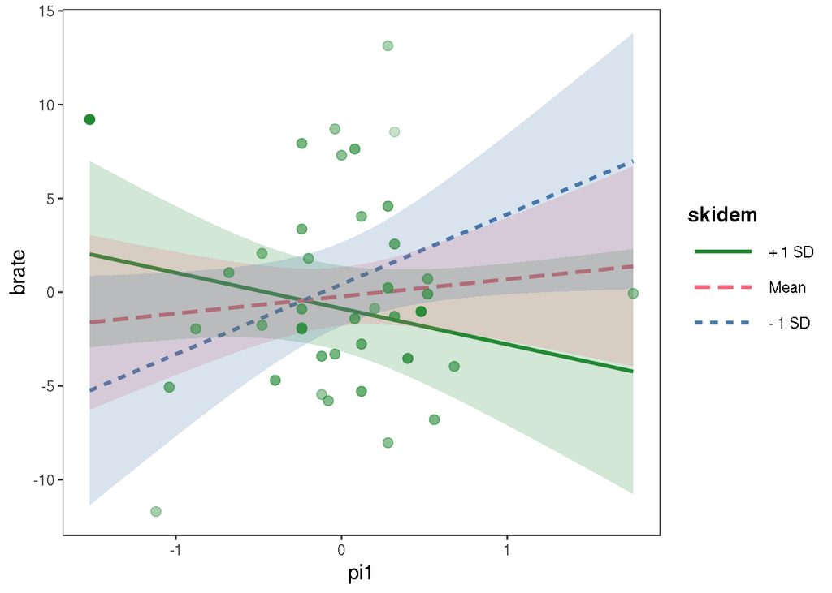

```r
ss <- sim_slopes(lmm.br.sp1, pred = "pi1", modx = "skidem", jnalpha = 0.05, johnson_neyman = TRUE, jnplot = TRUE, cond.int = TRUE)
interact_plot(lmm.br.sp1, pred = "pi1", modx = "skidem", centered = "none", interval = TRUE, plot.points = TRUE, color.class = "Qual2")
```

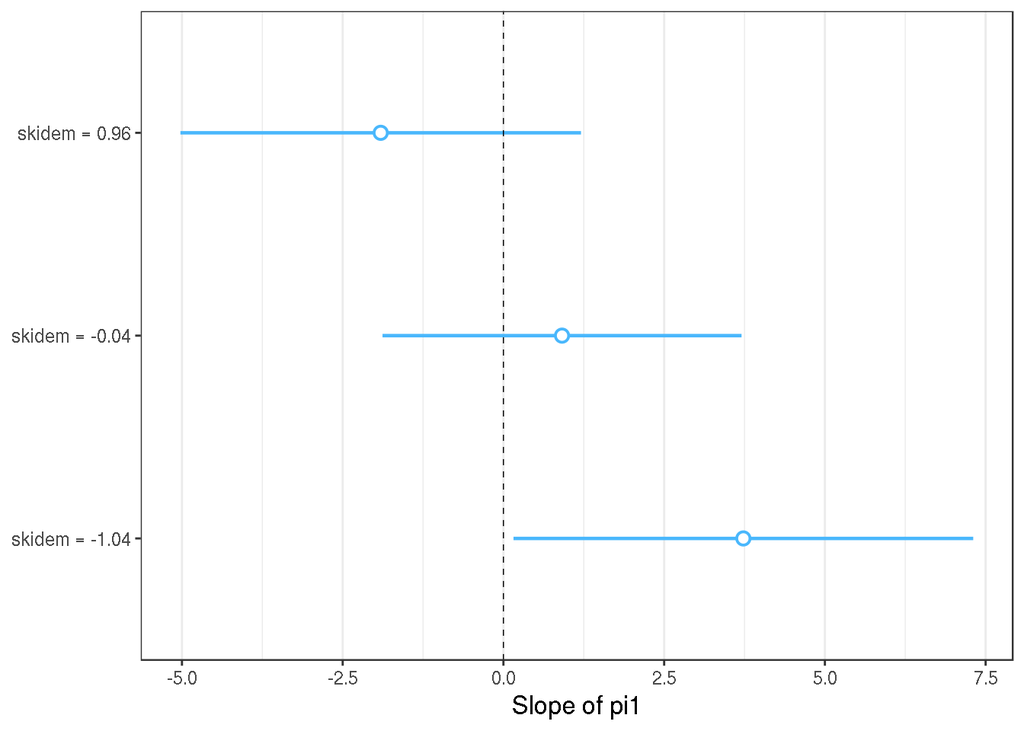

```r
plot(ss)
```

```r
as_huxtable(ss)
```

| Value of skidem | Slope of pi1 |
| --- | --- |
| 0.96 | -1.91 (1.59) |
| -0.04 | 0.91 (1.42) |
| -1.04 | 3.73 (1.82)# |

```r
ss
```

```
## JOHNSON-NEYMAN INTERVAL
##
## When skidem is OUTSIDE the interval [-1.03, 1.76], the slope of pi1 is
## p < .05.
##
## Note: The range of observed values of skidem is [-2.40, 3.00]
```

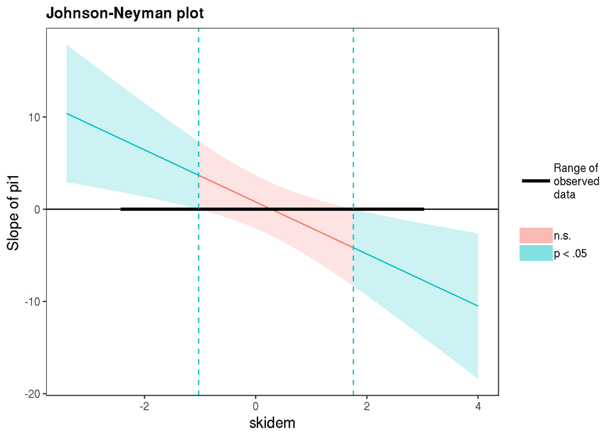

```
## SIMPLE SLOPES ANALYSIS
##
## Slope of pi1 when skidem =  0.96 (+ 1 SD):
##   Est. S.E.    df    p
##  -1.91 1.59 -1.20 0.24
## Conditional intercept when skidem =  0.96 (+ 1 SD):
##   Est. S.E.    df    p
##  -0.86 1.12 -0.76 0.45
##
## Slope of pi1 when skidem = -0.04 (Mean):
##  Est. S.E.   df    p
##  0.91 1.42 0.64 0.53
## Conditional intercept when skidem = -0.04 (Mean):
##   Est. S.E.    df    p
##  -0.24 0.77 -0.30 0.76
##
## Slope of pi1 when skidem = -1.04 (- 1 SD):
##  Est. S.E.   df    p
##  3.73 1.82 2.05 0.05
## Conditional intercept when skidem = -1.04 (- 1 SD):
##  Est. S.E.   df    p
##  0.39 1.10 0.35 0.73
```

```r
# BLINK RATE ~ SKIDEM * PI-2
cor(df$skidem, df$pi2)
```

```
## [1] -0.1437458
```

```r
lmm.br.sp2 <- lmer(brate ~ skidem*pi2 + (1 | Participant), data = df) # ***
summary(lmm.br.sp2)
```

```
## Linear mixed model fit by REML. t-tests use Satterthwaite's method [
## lmerModLmerTest]
## Formula: brate ~ skidem * pi2 + (1 | Participant)
##    Data: df
##
## REML criterion at convergence: 229
##
## Scaled residuals:
##      Min       1Q   Median       3Q      Max
## -1.65904 -0.71490 -0.02212  0.54970  2.47013
##
## Random effects:
##  Groups      Name        Variance  Std.Dev.
##  Participant (Intercept) 9.814e-31 9.907e-16
##  Residual                2.018e+01 4.492e+00
## Number of obs: 41, groups:  Participant, 9
##
## Fixed effects:
##             Estimate Std. Error      df t value Pr(>|t|)
## (Intercept)  -0.2969     0.7059 37.0000  -0.421 0.676477
## skidem        0.6312     0.7373 37.0000   0.856 0.397458
## pi2           1.0343     1.2533 37.0000   0.825 0.414514
## skidem:pi2   -4.2407     1.1523 37.0000  -3.680 0.000739 ***
## ---
## Signif. codes:  0 '***' 0.001 '**' 0.01 '*' 0.05 '.' 0.1 ' ' 1
##
## Correlation of Fixed Effects:
##            (Intr) skidem pi2
## skidem      0.016
## pi2         0.014  0.038
## skidem:pi2  0.100 -0.238  0.318
```

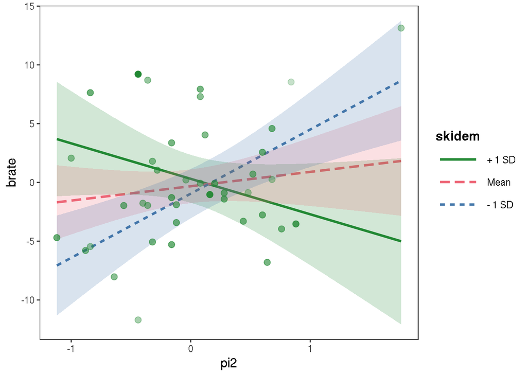

```r
ss <- sim_slopes(lmm.br.sp2, pred = "pi2", modx = "skidem", jnalpha = 0.05, johnson_neyman = TRUE, jnplot = TRUE, cond.int = TRUE)
interact_plot(lmm.br.sp2, pred = "pi2", modx = "skidem", centered = "none", interval = TRUE, plot.points = TRUE, color.class = "Qual2")
```

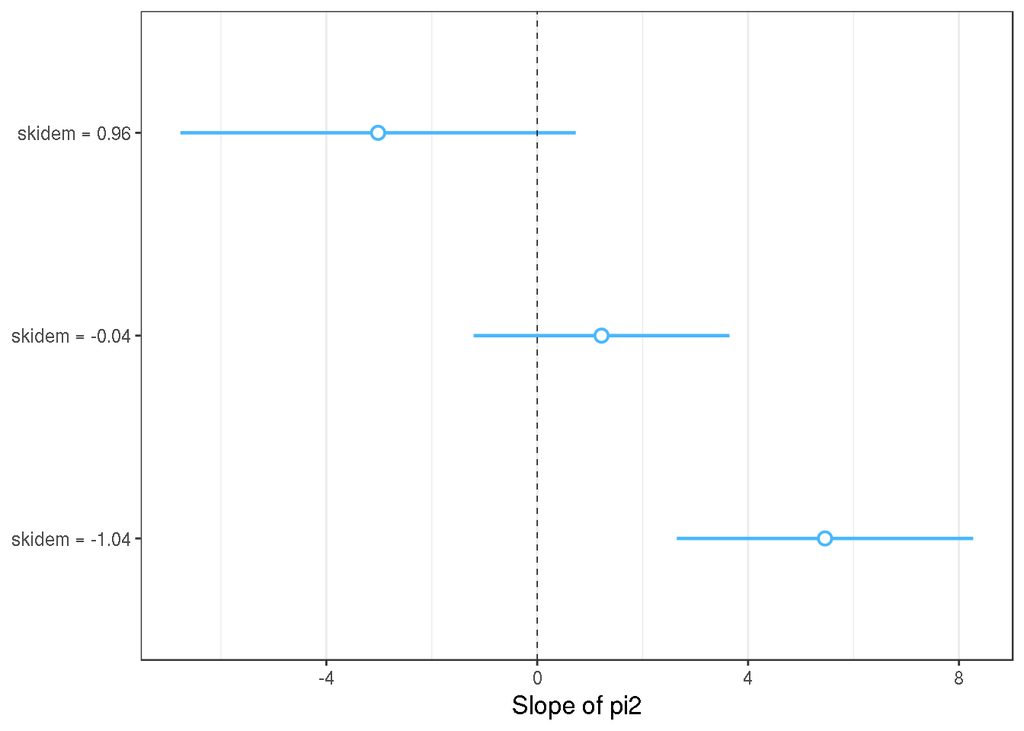

```r
plot(ss)
```

```r
as_huxtable(ss)
```

| Value of skidem | Slope of pi2 |
| --- | --- |
| 0.96 | -3.02 (1.91) |
| -0.04 | 1.22 (1.24) |
| -1.04 | 5.46 (1.43)*** |

```r
ss
```

```
## JOHNSON-NEYMAN INTERVAL
##
## When skidem is OUTSIDE the interval [-0.33, 1.33], the slope of pi2 is
## p < .05.
##
## Note: The range of observed values of skidem is [-2.40, 3.00]
```

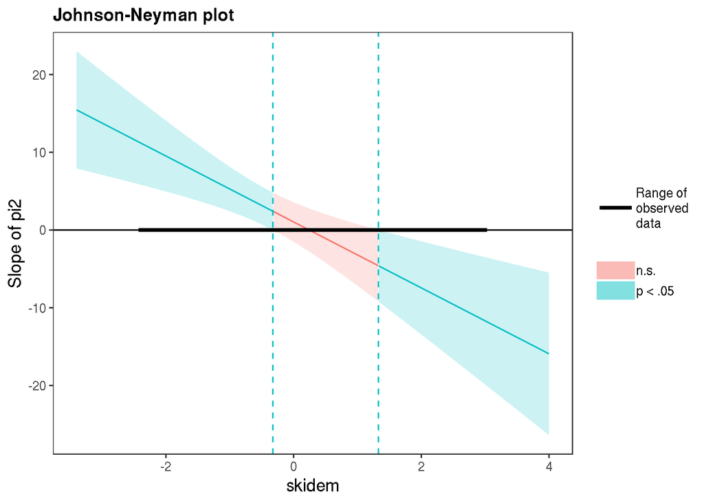

```
## SIMPLE SLOPES ANALYSIS
##
## Slope of pi2 when skidem =  0.96 (+ 1 SD):
##   Est. S.E.    df    p
##  -3.02 1.91 -1.58 0.12
## Conditional intercept when skidem =  0.96 (+ 1 SD):
##  Est. S.E.   df    p
##  0.26 1.00 0.26 0.80
##
## Slope of pi2 when skidem = -0.04 (Mean):
##  Est. S.E.   df    p
##  1.22 1.24 0.99 0.33
## Conditional intercept when skidem = -0.04 (Mean):
##   Est. S.E.    df    p
##  -0.31 0.71 -0.43 0.67
##
## Slope of pi2 when skidem = -1.04 (- 1 SD):
##  Est. S.E.   df    p
##  5.46 1.43 3.81 0.00
## Conditional intercept when skidem = -1.04 (- 1 SD):
##   Est. S.E.    df    p
##  -0.88 1.03 -0.85 0.40
```

## RQ3

“Does sEBR variation across sessions, and actual performance (i.e. duration, session-wise power-law slope), affect perceived cognitive performance (Flow, PI, skill:demand)?”

Extending the approach above, we can then look at some performance measures in a three-way interaction.

```r
fiti <- lmer(duration ~ brate*skill*pi1 + (1 | Participant), data = df)       # **
summ(fiti)
```

```
## MODEL INFO:
## Observations: 41
## Dependent Variable: duration
## Type: Mixed effects linear regression
##
## MODEL FIT:
## AIC = 293.53, BIC = 310.66
## Pseudo-R² (fixed effects) =
## Pseudo-R² (total) =
##
## FIXED EFFECTS:
##                   Est. S.E.    df d.f.    p
## (Intercept)       0.70 1.74  0.40   33 0.69
## brate            -0.69 0.37 -1.88   33 0.07   .
## skill           -20.55 3.48 -5.91   33 0.00 ***
## pi1              11.16 3.03  3.68   33 0.00 ***
## brate:skill       0.87 0.61  1.42   33 0.17
## brate:pi1        -2.05 0.60 -3.43   33 0.00  **
## skill:pi1       -11.87 8.84 -1.34   33 0.19
## brate:skill:pi1  -3.42 1.72 -1.99   33 0.06   .
##
## p values calculated using Satterthwaite d.f.
##
## RANDOM EFFECTS:
##        Group   Parameter Std. Dev.
##  Participant (Intercept)      0.00
##     Residual                  9.54
##
## Grouping variables:
##        Group # groups  ICC
##  Participant        9 0.00
```

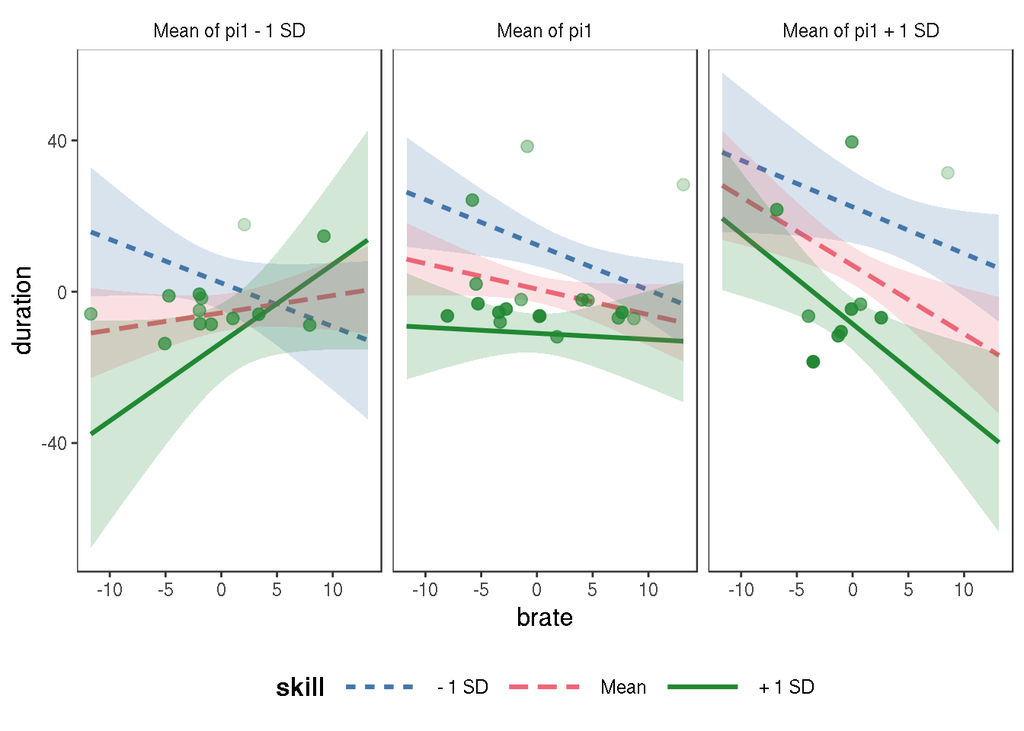

```r
ss <- sim_slopes(fiti, pred = "brate", modx = "skill", mod2 = "pi1", jnalpha = 0.05, johnson_neyman = TRUE, jnplot = TRUE, cond.int = TRUE)
interact_plot(fiti, pred = "brate", modx = "skill", mod2 = "pi1", centered = "none", interval = TRUE, plot.points = TRUE, color.class = "Qual2")
```

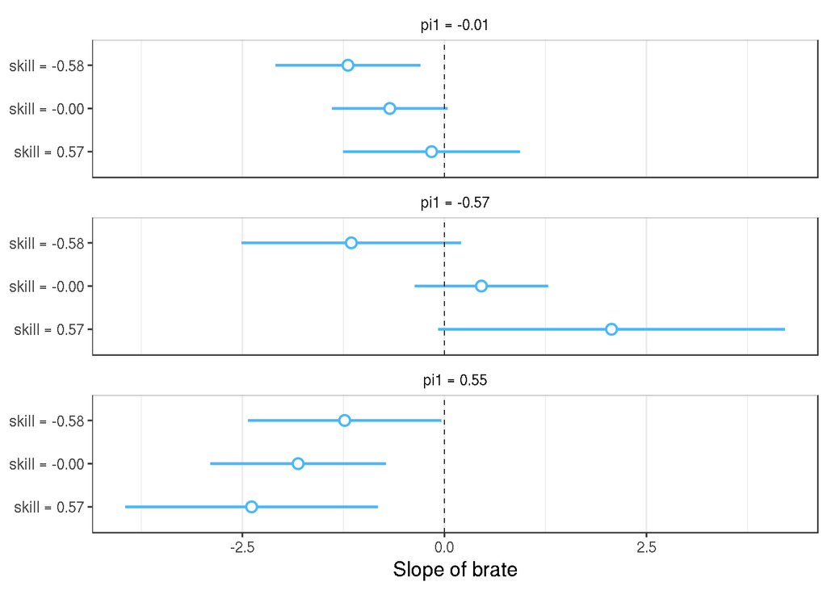

```r
plot(ss)
```

```r
as_huxtable(ss)
```

| pi1 = -0.57 |  |
| --- | --- |
| Value of skill | Slope of brate |
| -0.58 | -1.15 (0.69) |
| -0.00 | 0.46 (0.42) |
| 0.57 | 2.07 (1.1)# |
| pi1 = -0.01 |  |
| Value of skill | Slope of brate |
| -0.58 | -1.19 (0.46)* |
| -0.00 | -0.68 (0.37)# |
| 0.57 | -0.16 (0.56) |
| pi1 = 0.55 |  |
| Value of skill | Slope of brate |
| -0.58 | -1.23 (0.61)# |
| -0.00 | -1.81 (0.56)*** |
| 0.57 | -2.39 (0.8)* |

```r
ss
```

```
## █████████████████████████████████████████████████████ While pi1 (2nd moderator) = -0.57 (- 1 SD) █████████████████████████████████████████████████████
##
## JOHNSON-NEYMAN INTERVAL
##
## The Johnson-Neyman interval could not be found.  Is the p value for
## your interaction term below the specified alpha?
##
## SIMPLE SLOPES ANALYSIS
##
## Slope of brate when skill = -0.58 (- 1 SD):
##   Est. S.E.    df    p
##  -1.15 0.69 -1.66 0.11
## Conditional intercept when skill = -0.58 (- 1 SD):
##  Est. S.E.   df    p
##  2.33 3.54 0.66 0.52
##
## Slope of brate when skill = -0.00 (Mean):
##  Est. S.E.   df    p
##  0.46 0.42 1.09 0.29
## Conditional intercept when skill = -0.00 (Mean):
##   Est. S.E.    df    p
##  -5.57 2.41 -2.31 0.03
##
## Slope of brate when skill =  0.57 (+ 1 SD):
##  Est. S.E.   df    p
##  2.07 1.10 1.89 0.07
## Conditional intercept when skill =  0.57 (+ 1 SD):
##    Est. S.E.    df    p
##  -13.46 5.06 -2.66 0.01
##
## ██████████████████████████████████████████████████████ While pi1 (2nd moderator) = -0.01 (Mean) ██████████████████████████████████████████████████████
##
## JOHNSON-NEYMAN INTERVAL
##
## When skill is INSIDE the interval [-1.93, -0.07], the slope of brate
## is p < .05.
##
## Note: The range of observed values of skill is [-1.40, 1.00]
##
## SIMPLE SLOPES ANALYSIS
```

[output cut: 38 more lines]

```
##  22.42 4.68 4.79 0.00
##
## Slope of brate when skill = -0.00 (Mean):
##   Est. S.E.    df    p
##  -1.81 0.56 -3.26 0.00
## Conditional intercept when skill = -0.00 (Mean):
##  Est. S.E.   df    p
##  6.95 2.45 2.84 0.01
##
## Slope of brate when skill =  0.57 (+ 1 SD):
##   Est. S.E.    df    p
##  -2.39 0.80 -2.99 0.01
## Conditional intercept when skill =  0.57 (+ 1 SD):
##   Est. S.E.    df    p
##  -8.52 3.37 -2.53 0.02
```

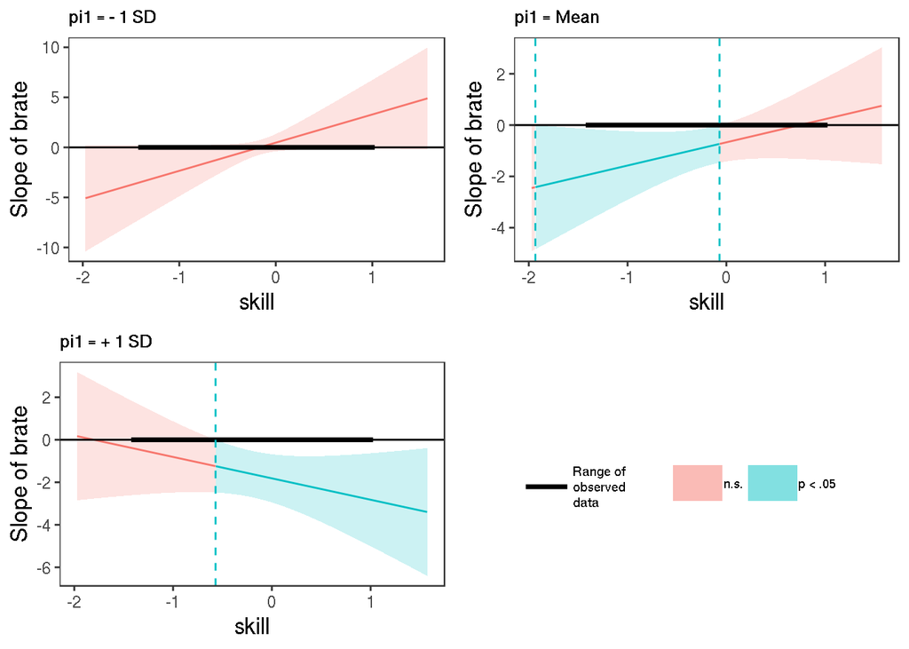

## RQ4

“Does sEBR variation across sessions, and expected-performance difference (i.e. LC-to-duration distance) affect perceived cognitive performance (Flow, PI, skill:demand)?”

For the ‘distance’ measure of deviation from expected performance (aggregated from the run-level metric reported in paper 1), we see a 2-way interaction of sEBR and PI:

```r
fiti <- lmer(distance ~ brate*pi2 + (1 | Participant), data = df)    # **
summ(fiti)
```

```
## MODEL INFO:
## Observations: 41
## Dependent Variable: distance
## Type: Mixed effects linear regression
##
## MODEL FIT:
## AIC = -179.17, BIC = -168.89
## Pseudo-R² (fixed effects) =
## Pseudo-R² (total) =
##
## FIXED EFFECTS:
##              Est. S.E.    df d.f.    p
## (Intercept)  0.00 0.00  0.08   37 0.94
## brate       -0.00 0.00 -0.24   37 0.81
## pi2         -0.01 0.00 -3.29   37 0.00 **
## brate:pi2    0.00 0.00  2.85   37 0.01 **
##
## p values calculated using Satterthwaite d.f.
##
## RANDOM EFFECTS:
##        Group   Parameter Std. Dev.
##  Participant (Intercept)      0.00
##     Residual                  0.01
##
## Grouping variables:
##        Group # groups  ICC
##  Participant        9 0.00
```

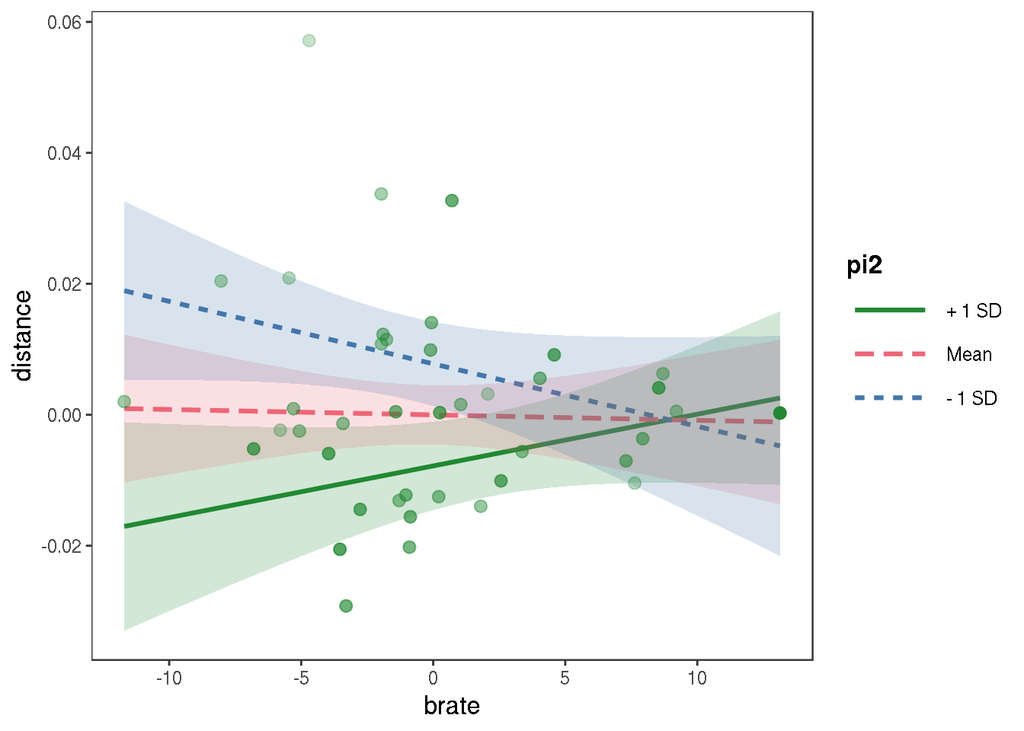

```r
ss <- sim_slopes(fiti, pred = "brate", modx = "pi2", jnalpha = 0.05, johnson_neyman = TRUE, jnplot = TRUE, cond.int = TRUE)
interact_plot(fiti, pred = "brate", modx = "pi2", centered = "none", interval = TRUE, plot.points = TRUE, color.class = "Qual2")
```

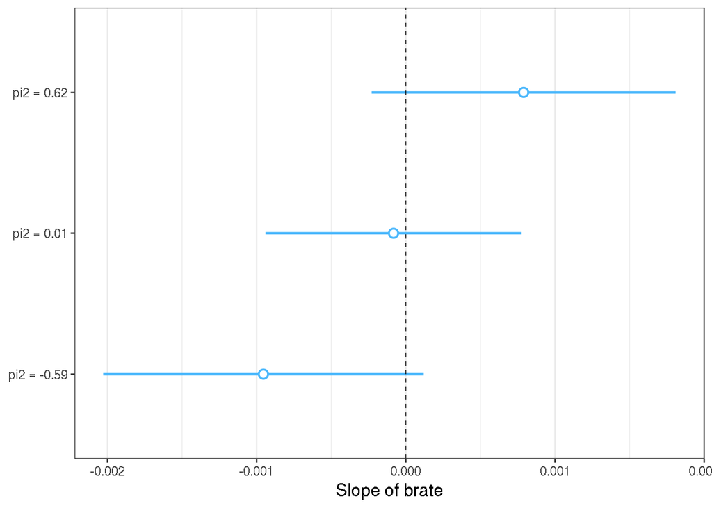

```r
plot(ss)
```

```r
as_huxtable(ss)
```

| Value of pi2 | Slope of brate |
| --- | --- |
| 0.62 | 0 (0) |
| 0.01 | 0 (0) |
| -0.59 | 0 (0)# |

```r
ss
```

```
## JOHNSON-NEYMAN INTERVAL
##
## When pi2 is OUTSIDE the interval [-0.79, 0.95], the slope of brate is
## p < .05.
##
## Note: The range of observed values of pi2 is [-1.12, 1.76]
```

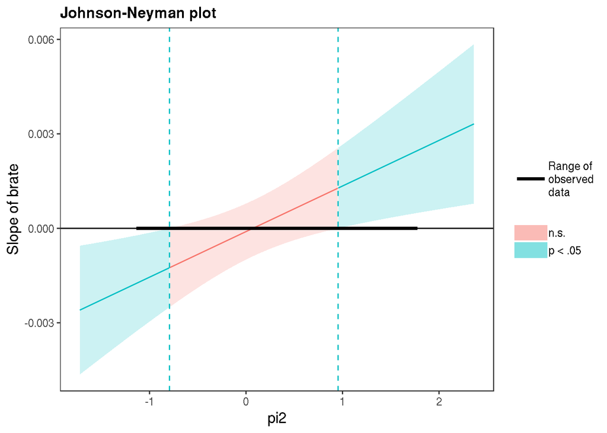

```
## SIMPLE SLOPES ANALYSIS
##
## Slope of brate when pi2 =  0.62 (+ 1 SD):
##  Est. S.E.   df    p
##  0.00 0.00 1.52 0.14
## Conditional intercept when pi2 =  0.62 (+ 1 SD):
##   Est. S.E.    df    p
##  -0.01 0.00 -2.35 0.02
##
## Slope of brate when pi2 =  0.01 (Mean):
##   Est. S.E.    df    p
##  -0.00 0.00 -0.19 0.85
## Conditional intercept when pi2 =  0.01 (Mean):
##   Est. S.E.    df    p
##  -0.00 0.00 -0.01 0.99
##
## Slope of brate when pi2 = -0.59 (- 1 SD):
##   Est. S.E.    df    p
##  -0.00 0.00 -1.74 0.09
## Conditional intercept when pi2 = -0.59 (- 1 SD):
##  Est. S.E.   df    p
##  0.01 0.00 2.45 0.02
```

## Summary

The above analysis is obviously preliminary and doesn’t account for several possible issues. What is the underlying relationship that is producing these results? It’s not clear, and it could (with low probability) just be type 1 error.

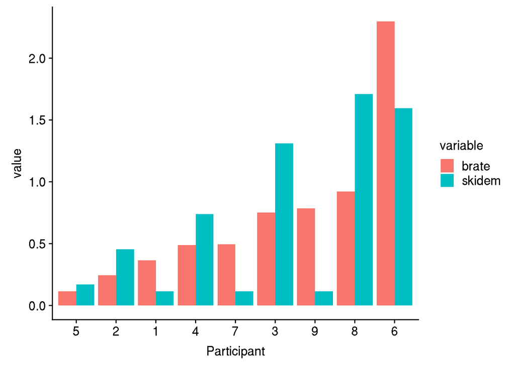

```r
## Check variance of key variables
dfvar <- group_by(df, Participant) %>%
  summarise_at(vars(brate, skidem), funs(var), na.rm = TRUE) %>%
  mutate_at(vars(brate, skidem), funs(scale), center = FALSE) %>%
  mutate_at(vars(brate, skidem), funs(drop))
dfvar$Participant <- factor(dfvar$Participant, levels = dfvar$Participant[order(dfvar$brate)])
# bar plot of key variable variance
dfv.m <- melt(dfvar, id.vars = "Participant")
ggplot(dfv.m, aes(Participant, value)) + geom_bar(aes(fill = variable), position = "dodge", stat="identity")
```